# Europe’s Largest Banks

Martin Geissmann

6 Mai 2019

# Loading the packages and getting the data

We use *tidyquant*.

We are interested in the following largest banks in Europe: [Gross, grösser, HSBC: Die 50 grössten Banken, die Europa zu bieten hat](https://www.msn.com/de-ch/finanzen/finance/gross-gr%C3%B6sser-hsbc-die-50-gr%C3%B6ssten-banken-die-europa-zu-bieten-hat/ar-AAAQuXY?ocid=ieslice#page=1)

- HSBC
- BNP Paribas
- Crédit Agricole
- Santander
- Deutsche Bank

Also we would like to have a look at UBS and Credit Suisse for comparison. The data is ready on [Yahoo Finance](https://finance.yahoo.com/).

```r
hsbc    <- tq_get("HSBC", from = "2009-01-01") # usd
paribas <- tq_get("BNP.PA", from = "2009-01-01")    # eur
credagr <- tq_get("ACA.PA", from = "2009-01-01")   # eur
santand <- tq_get("SAN", from = "2009-01-01") # usd
deutsch <- tq_get("DB", from = "2009-01-01") # usd

ubs     <- tq_get("UBS", from = "2009-01-01")
cs      <- tq_get("CS", from = "2009-01-01")
```

It is not note that the stocks listed in the US trade in USD. BNP Paribas and Credit Agricole on the other hand trade in EUR.

Ultimately we are interested in the return in CHF. Exchange rates are available form [FRED](https://fred.stlouisfed.org/). The tidyquant’s default data source which is [Oanda](https://www.oanda.com) only goes back 180 days, which would not be enough for us. The ticker has to be looked up on FRED.

```r
usd_eur <- tq_get("DEXUSEU",
                  get = "economic.data", from = "2009-01-01")

chf_usd <- tq_get("DEXSZUS",
                  get = "economic.data", from = "2009-01-01")
```

Finally, we create the following function which helps to convert the adjusted closing price in the desired currency.

```r
mutate_exchange <- function(data, exchangerates, inverse = F, datecol = "date", ratecol = "price", adjustedcol = "adjusted") {
  if (inverse) {
    exchangerates <- exchangerates %>% mutate(!!ratecol := 1/!!as.name(ratecol))
  }

  out <- left_join(data, exchangerates, by = "date") %>%
    mutate(!!ratecol := na.locf(!!as.name(ratecol))) %>%
    mutate(adjusted_ex = !!as.name(adjustedcol)/!!as.name(ratecol)) %>%
    select(-one_of("exrate")) %>%
    rename(exrate = !!as.name(ratecol))

  return(out)
}
```

Apply the currency convertion and bind all data together.

Note that Yahoo Finance gave some error error prices for UBS in 2014, which we remove manually.

Arithmetic and log daily returns are computed and stored in *returns*.

```r
data <- bind_rows(

  hsbc    %>%
    mutate_exchange(chf_usd, inverse = T) %>%
    mutate(stock = "HSBC") %>%
    select(date, stock, adjusted_ex),

  paribas %>%
    mutate_exchange(usd_eur, inverse = T) %>%
    mutate_exchange(chf_usd, inverse = T, adjustedcol = "adjusted_ex") %>%
    mutate(stock = "BNP Paribas") %>%
    select(date, stock, adjusted_ex),


  credagr %>%
    mutate_exchange(usd_eur, inverse = T) %>%
    mutate_exchange(chf_usd, inverse = T, adjustedcol = "adjusted_ex") %>%
    mutate(stock = "Crédit Agricole") %>%
    select(date, stock, adjusted_ex),

  santand %>%
    mutate_exchange(chf_usd, inverse = T) %>%
    mutate(stock = "Santander") %>%
    select(date, stock, adjusted_ex),

  deutsch %>%
    mutate_exchange(chf_usd, inverse = T) %>%
    mutate(stock = "Deutsche Bank") %>%
    select(date, stock, adjusted_ex),

  ubs     %>%
    mutate(adjusted = if_else(adjusted > 100, lag(adjusted, 7), adjusted)) %>%
    mutate_exchange(chf_usd, inverse = T) %>%
    mutate(stock = "UBS") %>%
    select(date, stock, adjusted_ex),

  cs      %>%
    mutate_exchange(chf_usd, inverse = T) %>%
    mutate(stock = "Credit Suisse") %>%
    select(date, stock, adjusted_ex)

)


returns <- data %>%
  arrange(stock, date) %>%
  group_by(stock) %>%
  mutate(return = adjusted_ex/lag(adjusted_ex)-1,
         return_ln = log(adjusted_ex/lag(adjusted_ex)))

# returns %>% saveRDS("returns.RDS")
```

# Performance plots

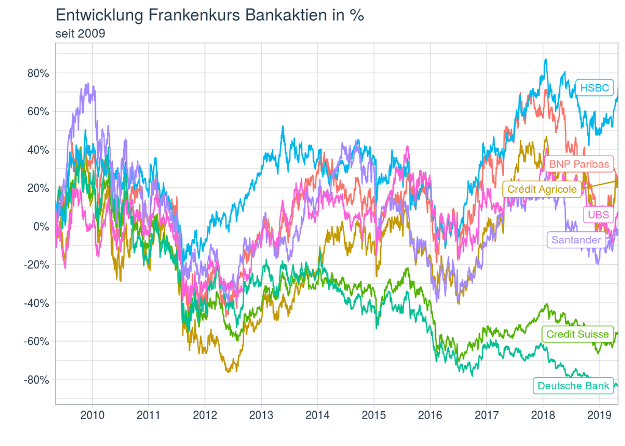

```r
# 10 years

returns_plot <- returns %>%
  filter(!is.na(return_ln),
         # cut-off date
         date >= "2009-05-06") %>%
  mutate(cumret_ln = cumsum(return_ln),
         adjusted_ln = exp(cumret_ln))

returns_plot %>%
  ggplot(aes(x = date, y = adjusted_ln-1, color = stock)) +
  geom_line() +
  geom_label_repel(aes(label = if_else(date == "2019-05-03", stock, NA_character_)),
                  size = 3) +
  # geom_text_repel(aes(label = stock, x = tail())) +
  scale_x_date(expand = c(0,0),
               date_breaks = "1 year",
               date_labels = "%Y") +
  scale_y_continuous(labels = scales::percent,
                     breaks = seq(-0.8, 0.9, by = 0.2)) +
  labs(x = "", y = "",
       title = "Entwicklung Frankenkurs Bankaktien in %",
       subtitle = "seit 2009") +
  theme_tq() +
  theme(legend.position = "none")
```

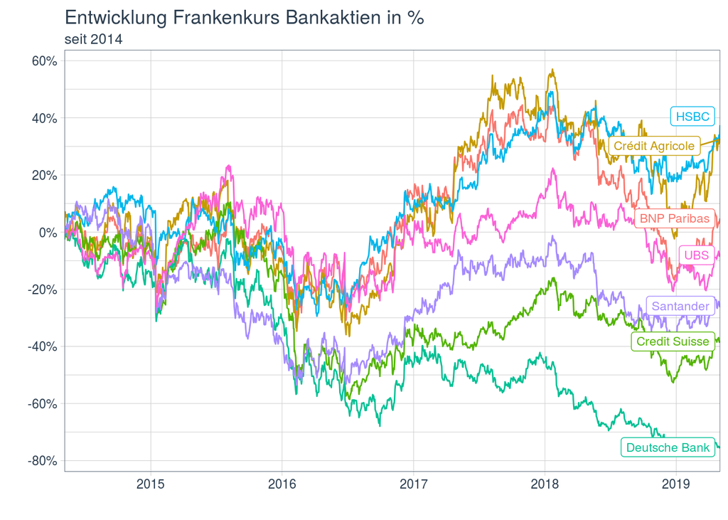

```r
# 5 years

returns_plot <- returns %>%
  filter(!is.na(return_ln),
         # cut-off date
         date >= "2014-05-06") %>%
  mutate(cumret_ln = cumsum(return_ln),
         adjusted_ln = exp(cumret_ln))

returns_plot %>%
  ggplot(aes(x = date, y = adjusted_ln-1, color = stock)) +
  geom_line() +
  geom_label_repel(aes(label = if_else(date == "2019-05-03", stock, NA_character_)),
                  size = 3) +
  # geom_text_repel(aes(label = stock, x = tail())) +
  scale_x_date(expand = c(0,0),
               date_breaks = "1 year",
               date_labels = "%Y") +
  scale_y_continuous(labels = scales::percent,
                     breaks = seq(-0.8, 0.9, by = 0.2)) +
  labs(x = "", y = "",
       title = "Entwicklung Frankenkurs Bankaktien in %",
       subtitle = "seit 2014") +
  theme_tq() +
  theme(legend.position = "none")
```

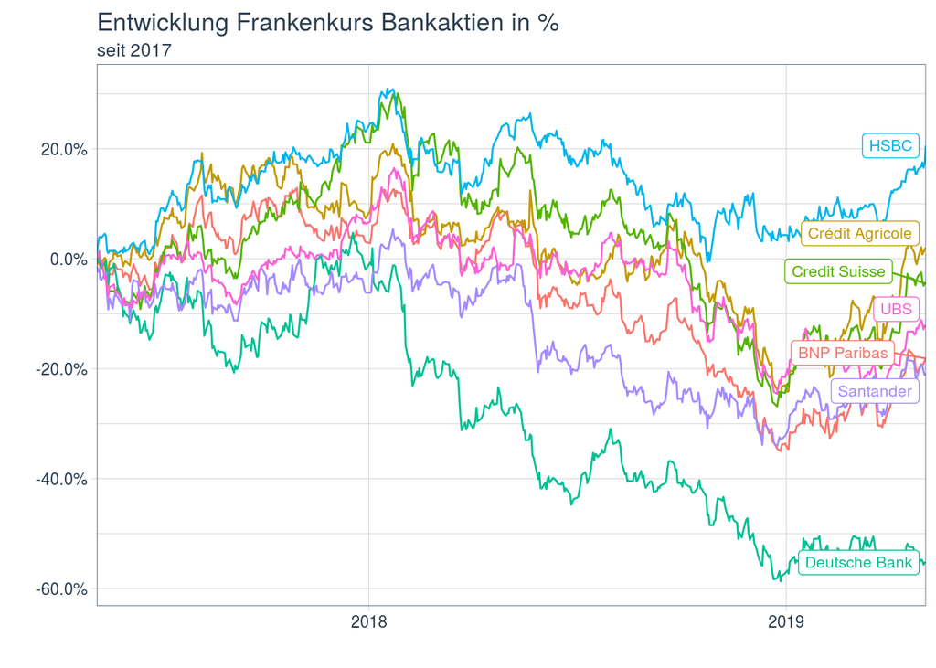

```r
# 2 years

returns_plot <- returns %>%
  filter(!is.na(return_ln),
         # cut-off date
         date >= "2017-05-06") %>%
  mutate(cumret_ln = cumsum(return_ln),
         adjusted_ln = exp(cumret_ln))

returns_plot %>%
  ggplot(aes(x = date, y = adjusted_ln-1, color = stock)) +
  geom_line() +
  geom_label_repel(aes(label = if_else(date == "2019-05-03", stock, NA_character_)),
                  size = 3) +
  # geom_text_repel(aes(label = stock, x = tail())) +
  scale_x_date(expand = c(0,0),
               date_breaks = "1 year",
               date_labels = "%Y") +
  scale_y_continuous(labels = scales::percent,
                     breaks = seq(-0.8, 0.9, by = 0.2)) +
  labs(x = "", y = "",
       title = "Entwicklung Frankenkurs Bankaktien in %",
       subtitle = "seit 2017") +
  theme_tq() +
  theme(legend.position = "none")
```

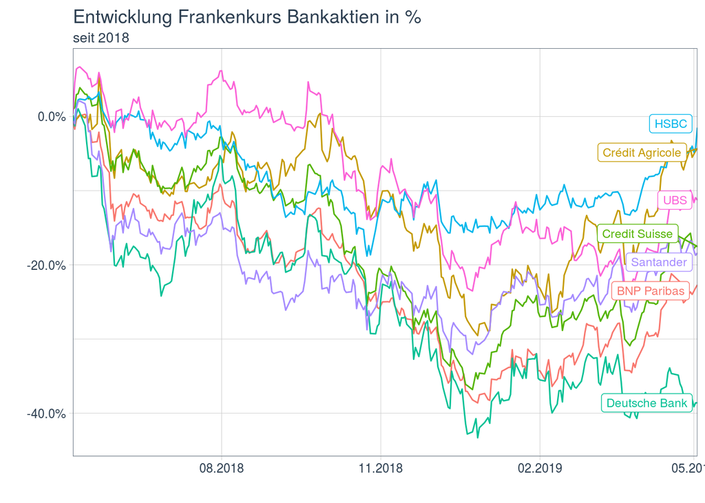

```r
# 1 year

returns_plot <- returns %>%
  filter(!is.na(return_ln),
         # cut-off date
         date >= "2018-05-06") %>%
  mutate(cumret_ln = cumsum(return_ln),
         adjusted_ln = exp(cumret_ln))


returns_plot %>%
  ggplot(aes(x = date, y = adjusted_ln-1, color = stock)) +
  geom_line() +
  geom_label_repel(aes(label = if_else(date == "2019-05-03", stock, NA_character_)),
                  size = 3) +
  # geom_text_repel(aes(label = stock, x = tail())) +
  scale_x_date(expand = c(0,0),
               date_breaks = "3 months",
               date_labels = "%m.%Y") +
  scale_y_continuous(labels = scales::percent,
                     breaks = seq(-0.8, 0.9, by = 0.2)) +
  labs(x = "", y = "",
       title = "Entwicklung Frankenkurs Bankaktien in %",
       subtitle = "seit 2018") +
  theme_tq() +
  theme(legend.position = "none")
```